# Exploratory Data Analysis (EDA) — Prediksi Potensi Recharge Channel Perbankan

**Proyek:** Praktikum Sains Data (STA1581) — Tim `KAGGLE_AUTO_WIN`  
**Dataset:** `training_data_tugas_praktikum_DataScience.csv` (45.000 baris) & `testing_data_tugas_praktikum_DataScience.csv` (5.000 baris)  
**Metrik Evaluasi Kompetisi:** *Balanced Accuracy*

## Tahap 1: Pemuatan Data & Pemeriksaan Kualitas Data (Data Integrity Audit)

Tahap pertama membaca dataset *training* dan *testing*, memeriksa nilai hilang (*missing values*), baris duplikat, serta memeriksa struktur pengurutan kolom `ID` terhadap variabel respon `Y`.

```
train_df <- read.csv('data/training_data_tugas_praktikum_DataScience.csv')
test_df  <- read.csv('data/testing_data_tugas_praktikum_DataScience.csv')
sum(is.na(train_df)); sum(is.na(test_df))
range(train_df$ID[train_df$Y == 0]); range(train_df$ID[train_df$Y == 1])
```

**Temuan Kritis #1 (Target Leakage pada ID & Class Imbalance):**

- **Tidak ada Missing Values (NA = 0)** di seluruh 45.000 baris data *training* maupun 5.000 baris data *testing*.
- **Class Imbalance (4,36 : 1):** Kelas `Y = 0` berjumlah **36.598 pelanggan (81,33%)** dan kelas `Y = 1` berjumlah **8.402 pelanggan (18,67%)**.
- **Urutan Baris Data Training Terurut Penuh Berdasarkan Y:** Baris `ID 1–36.598` semuanya bernilai `Y = 0`, sedangkan baris `ID 36.599–45.000` semuanya bernilai `Y = 1`. Sebaliknya, data *testing* (`ID 45.001–50.000`) sudah diacak. Oleh karena itu, **kolom ID wajib dibuang dari pemodelan** dan validasi lokal wajib memakai **Stratified K-Fold Cross-Validation yang diacak (shuffled)**.

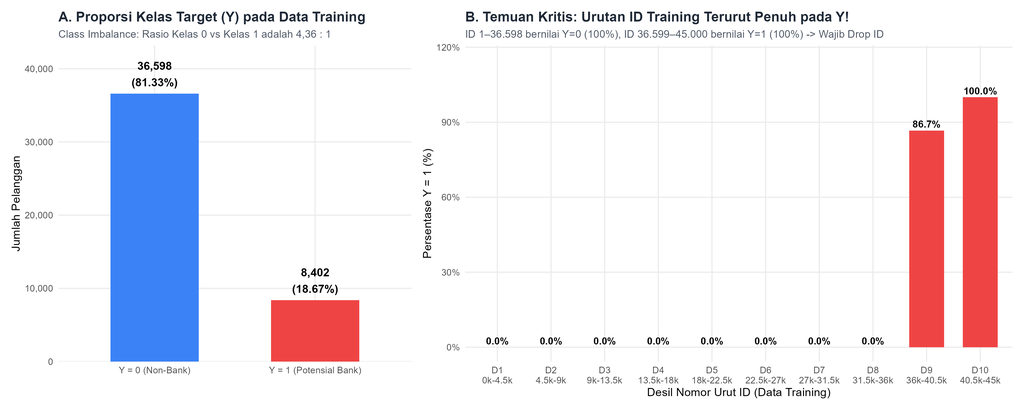

## Tahap 2: Statistik Deskriptif & Perbandingan Kelas (Y = 0 vs Y = 1)

Kita menghitung rata-rata, median, kuartil (Q25, Q75), kecondongan (*skewness*), uji non-parametrik *Wilcoxon Rank-Sum*, serta statistik *Kolmogorov-Smirnov (KS)* untuk mengukur daya pisah tiap fitur terhadap kelas `Y`.

```
# Contoh perhitungan uji perbandingan distribusi kelas dan korelasi
wilcox.test(x[y == 1], x[y == 0])
ks.test(x[y == 1], x[y == 0])
cor(x, y, method = 'spearman')
```

| Variabel | Deskripsi | Mean_Y0 | Mean_Y1 | Diff_Mean_Pct | Median_Y0 | Median_Y1 | Q25_Y0 | Q75_Y0 | Q25_Y1 | Q75_Y1 | Pearson_r | Spearman_rho | Wilcoxon_p_value | KS_Class_Stat | KS_TrainTest_Stat | KS_TrainTest_pval |
| --- | --- | --- | --- | --- | --- | --- | --- | --- | --- | --- | --- | --- | --- | --- | --- | --- |
| X9 | X9: Revenue Data (Rp/bln) | 13208.0675 | 29094.4142 | 120.28 | 1010.0000 | 20000.0000 | 0.0000 | 19838.7500 | 140.0000 | 42811.7500 | 0.2314 | 0.2194 | 0.00e+00 | 0.2606 | 0.0184 | 0.0943 |
| X8 | X8: Pemakaian Data (MB/bln) | 813.7747 | 1537.5971 | 88.95 | 37.0000 | 543.0000 | 0.0000 | 715.0000 | 12.0000 | 1972.7500 | 0.1248 | 0.1926 | 0.00e+00 | 0.2259 | 0.0192 | 0.0730 |
| X10 | X10: Frekuensi Recharge (kali/bln) | 7.5036 | 5.4651 | -27.17 | 6.3000 | 4.3000 | 4.0000 | 10.0000 | 2.7000 | 7.0000 | -0.1642 | -0.1866 | 0.00e+00 | 0.2118 | 0.0119 | 0.5433 |
| X11 | X11: Jumlah Wilayah Dikunjungi (/bln) | 3.8457 | 2.9555 | -23.15 | 3.3000 | 2.3000 | 2.3000 | 5.0000 | 1.7000 | 3.7000 | -0.1433 | -0.1812 | 0.00e+00 | 0.2066 | 0.0069 | 0.9820 |
| X5 | X5: Proporsi Panggilan On-Net | 0.8906 | 0.8504 | -4.51 | 0.9761 | 0.9352 | 0.8741 | 0.9981 | 0.7849 | 0.9889 | -0.0807 | -0.1323 | 0.00e+00 | 0.1551 | 0.0210 | 0.0372 |
| X7 | X7: Proporsi SMS On-Net | 0.7780 | 0.7477 | -3.89 | 0.8734 | 0.8162 | 0.6500 | 0.9854 | 0.6108 | 0.9565 | -0.0463 | -0.0728 | 0.00e+00 | 0.0963 | 0.0123 | 0.5074 |
| X4 | X4: Proporsi Panggilan Jam Kerja | 0.7313 | 0.7479 | 2.28 | 0.7476 | 0.7622 | 0.6958 | 0.7974 | 0.7063 | 0.8186 | 0.0467 | 0.0691 | 0.00e+00 | 0.0918 | 0.0178 | 0.1139 |
| X6 | X6: Revenue SMS (Rp/bln) | 6947.7311 | 5868.5751 | -15.53 | 4156.0000 | 3324.5000 | 1489.0000 | 9633.0000 | 1194.0000 | 7687.0000 | -0.0532 | -0.0586 | 0.00e+00 | 0.0714 | 0.0136 | 0.3740 |
| X2 | X2: Revenue Panggilan (Rp/bln) | 26780.7786 | 32679.2360 | 22.02 | 21737.0000 | 23730.0000 | 10744.2500 | 35395.7500 | 9964.5000 | 43228.7500 | 0.0842 | 0.0423 | 0.00e+00 | 0.0865 | 0.0142 | 0.3244 |
| X3 | X3: Frekuensi Panggilan (kali/bln) | 40.2147 | 39.6431 | -1.42 | 24.0000 | 22.0000 | 10.0000 | 50.0000 | 8.0000 | 49.0000 | -0.0044 | -0.0298 | 0.00e+00 | 0.0463 | 0.0142 | 0.3225 |
| X1 | X1: Durasi Panggilan (menit/bln) | 111.8221 | 105.8700 | -5.32 | 48.0000 | 44.0000 | 14.0000 | 132.0000 | 12.0000 | 127.0000 | -0.0128 | -0.0190 | 5.82e-05 | 0.0274 | 0.0086 | 0.8951 |

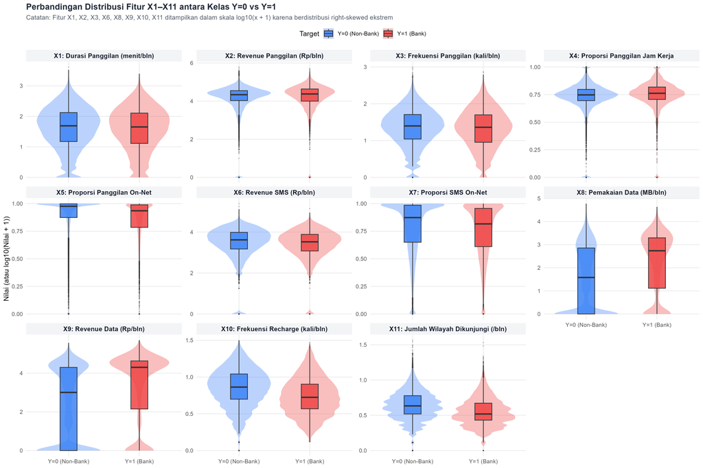

**Interpretasi Distribusi Fitur:**

- **X9 (Revenue Data) & X8 (Pemakaian Data MB):** Pembeda terkuat antara kedua kelas. Median belanja data pelanggan `Y = 1` mencapai **Rp 20.000/bulan** (dibandingkan `Y = 0` yang hanya **Rp 1.010/bulan** — hampir 20x lipat lebih tinggi!).
- **X10 (Frekuensi Recharge) & X11 (Wilayah Dikunjungi):** Memiliki hubungan negatif yang kuat dengan `Y`. Pelanggan `Y = 1` lebih jarang mengisi pulsa (median `4,3 kali/bulan` vs `6,3 kali/bulan`) dan memiliki mobilitas wilayah yang lebih stabil (median `2,3 wilayah` vs `3,3 wilayah`).
- **X2 (Revenue Panggilan) vs X5 (Proporsi On-Net):** Walaupun durasi telepon (`X1`) pelanggan `Y = 1` sedikit lebih rendah, pengeluaran telepon (`X2`) mereka **22% lebih tinggi** karena mereka lebih sering menelepon lintas operator (*off-net*, `1 - X5` lebih besar).

## Tahap 3: Analisis Korelasi & Multikolinearitas Antar-Variabel

Mengingat sebagian besar fitur berdistribusi menceng kanan ekstrem (*skewness* > 3), korelasi peringkat *Spearman* digunakan bersama korelasi linear *Pearson* untuk mendeteksi hubungan monotonik dan multikolinearitas.

```
cor_mat <- round(cor(train_df[, c(paste0('X', 1:11), 'Y')], method = 'spearman'), 4)
```

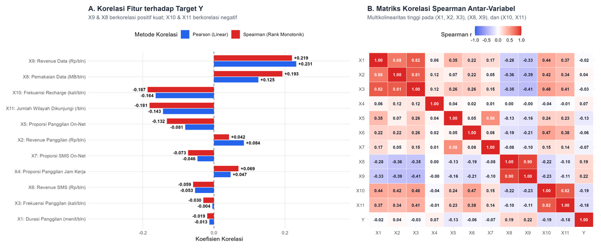

**Struktur Multikolinearitas:**  
Terdapat 3 klaster fitur yang saling berkorelasi tinggi: (1) Klaster Suara `X1, X2, X3` (ρ = 0,68–0,82), (2) Klaster Data `X8, X9` (ρ = 0,90), dan (3) Klaster Isi Ulang & Mobilitas `X10, X11` (ρ = 0,82). Pada model linear/regresi logistik, multikolinearitas ini perlu ditangani dengan regularisasi (*Lasso/Ridge/ElasticNet*) atau transformasi rasio.

## Tahap 4: Audit Zero-Inflation, Pola Desimal 1/3, & Segmen Perilaku

Pemeriksaan mendalam menemukan adanya kelompok pelanggan bernilai nol (*zero-inflated*) serta artefak pembulatan rata-rata 3 bulan (di mana `X10` dan `X11` selalu berakhir dengan `.0`, `.3`, atau `.7`).

| Segmen | Train_N | Train_Pct | Test_N | Test_Pct | Y1_Rate_Pct |
| --- | --- | --- | --- | --- | --- |
| 1. Non-Data Users (X8 == 0 & X9 == 0) | 14664 | 32.59 | 1704 | 34.08 | 11.39 |
| 2. Active Data Users (X8 > 0 \| X9 > 0) | 30336 | 67.41 | 3296 | 65.92 | 22.19 |
| 3. Durasi Bulat 0 tapi Ada Panggilan (X1 == 0 & X3 > 0) | 1022 | 2.27 | 113 | 2.26 | 21.23 |
| 4. Frekuensi Bulat 0 tapi Durasi > 0 (X3 == 0 & X1 > 0) | 44 | 0.10 | 5 | 0.10 | 15.91 |
| 5. Tanpa Panggilan sama sekali (X1 == 0 & X2 == 0 & X3 == 0) | 670 | 1.49 | 89 | 1.78 | 13.88 |
| 6. Tanpa Panggilan tapi X4 == 1 & X5 == 1 (Anomali Encoding) | 175 | 0.39 | 15 | 0.30 | 20.57 |
| 7. Tanpa SMS sama sekali (X6 == 0) | 1099 | 2.44 | 131 | 2.62 | 15.47 |
| 8. Pemakaian Data Gratis / Bonus (X8 > 0 & X9 == 0) | 144 | 0.32 | 20 | 0.40 | 27.08 |

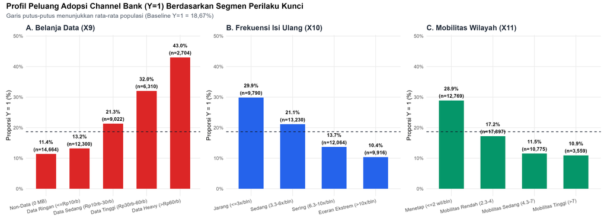

## Tahap 5: Pemeriksaan Covariate Shift (Data Training vs Data Testing)

Untuk memastikan model tidak mengalami penurunan performa saat diuji pada data *testing*, kita membandingkan fungsi kepadatan distribusi (*density plot*) dan uji *Kolmogorov-Smirnov* antara `Train` (45.000 baris) dan `Test` (5.000 baris).

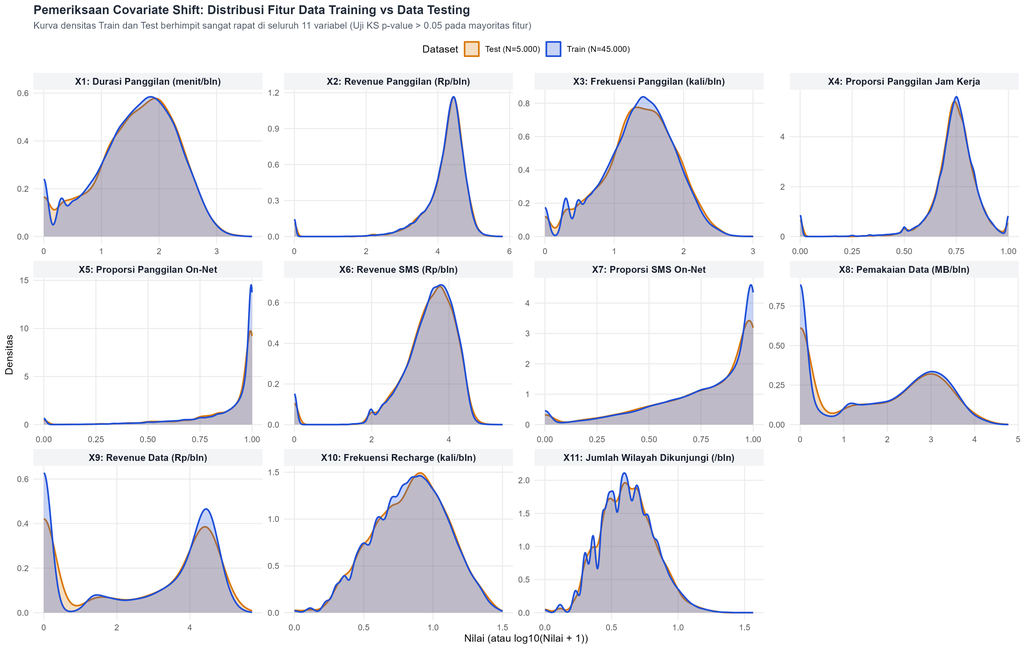

**Kesimpulan Kestabilan Distribusi:**  
Seluruh 11 fitur menunjukkan kurva distribusi yang berhimpit sangat rapat antara *Train* dan *Test* (statistik `KS_TrainTest` sangat kecil, berkisar `0,0069`–`0,0210`). Tidak ditemukan adanya *covariate shift*.

## Tahap 6: Sintesis Insight untuk Feature Engineering & Strategi Pemodelan

Menggabungkan total pengeluaran bulanan (`Total_Spend = X2 + X6 + X9`) dengan frekuensi isi ulang (`X10`) menghasilkan fitur kunci **Estimasi Nominal per Sekali Isi Ulang (*Estimated Ticket Size*)** serta **Porsi Pengeluaran Data (*Data Share*)**.

```
Total_Spend     = X2 + X6 + X9
Est_Ticket_Size = Total_Spend / pmax(X10, 0.3333)
Data_Share      = ifelse(Total_Spend > 0, X9 / Total_Spend, 0)
```

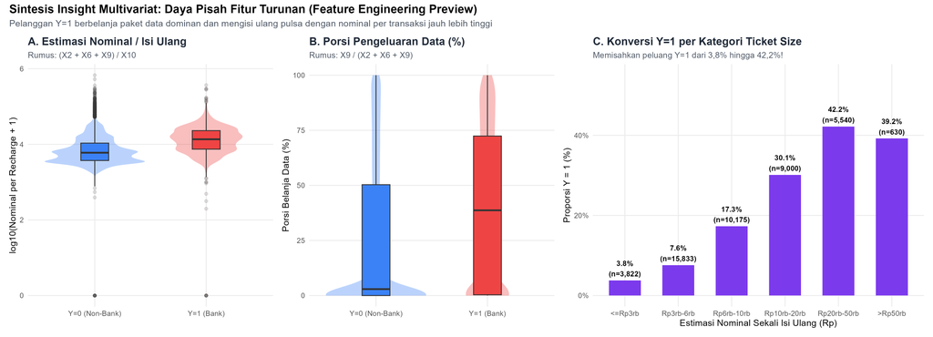

**Rekomendasi Langsung untuk Tahap Selanjutnya:**

1. **Feature Engineering (`feature_engineering_script/`):** Buat fitur rasio ekonomi (*Ticket Size per Recharge*, *Total ARPU*, *Share Voice/SMS/Data*, *Tarif Efektif per Menit/Panggilan/MB*, *Off-Net Call & SMS Volume/Spend*, rekonstruksi angka bulat 3 bulan `round(X10*3)` dan `round(X11*3)`, serta *flag* indikator *Zero-Data* dan anomali pembulatan).
2. **Modeling & Hyperparameter Tuning (`modeling_script/`):** Gunakan *Stratified K-Fold CV* (tanpa kolom `ID`), bandingkan `caret` baseline & *Gradient Boosted Trees* (`xgboost`, `randomForest`, `glmnet`), serta lakukan **Threshold Tuning** untuk memaksimalkan **Balanced Accuracy**.